# Analyzing time-series phonetic data

Miao

2/7/2022

# Introduction

This tutorial aims to give students a rough idea of the entire progress of analyzing time-series data in phonetics. Now let’s turn to data importing, cleaning, and plotting in R.

The raw F0 and formant data can be obtained by using the praat scripts that I put in the praat_scripts folder. Feel free to run the scripts to measure F0 and formants. However, all the data we need in R are already available in the data folder.

First, we need to load tidyverse and cowplot packages. If you haven’t got tidyverse and cowplot, use the code below to install them.

```r
#install.packages("tidyverse") #Uncomment this one by deleting the # at the beginning of the line if you want to install tidyverse.
#install.packages("cowplot") #Same as above
```

Load them into the working environment.

```r
library(tidyverse)
library(cowplot)
```

Let’s take a look at the f0 data first.

# F0

## Data import

Now we first need to import the data. We are going to use the function read_delim() from readr package which is a part of tidyverse. Because the data is delimited by tab, we will specify the ‘delim’ to “\\t” which means “tab”. By putting parentheses around the entire codes below, We are able to not only run the codes but also let R show the result, even when you saved the results to an R object.

```r
(f0_data <- read_delim("data/tones_f0t.txt", delim = "\t", col_types = cols(
  Segment = col_factor() #The Segment column is the column that includes the information of different tones so it should be formatted to factors instead of characters as in read_delim() default.
)) %>% #
  rename(Tone = Segment)) #Rename Segment column to Tone.
```

```
## # A tibble: 2,000 x 6
##    File_name Tone      t   t_m    F0   Int
##    <chr>     <fct> <dbl> <dbl> <dbl> <dbl>
##  1 GJF_si13  t13       1 0.016  88.1  63.3
##  2 GJF_si13  t13       2 0.048  87.4  65.6
##  3 GJF_si13  t13       3 0.079  87.7  67.0
##  4 GJF_si13  t13       4 0.111  88.7  68.0
##  5 GJF_si13  t13       5 0.143  89.6  68.8
##  6 GJF_si13  t13       6 0.174  NA    70.8
##  7 GJF_si13  t13       7 0.206  NA    74.0
##  8 GJF_si13  t13       8 0.238  NA    75.5
##  9 GJF_si13  t13       9 0.269 128.   75.9
## 10 GJF_si13  t13      10 0.301 128.   74.7
## # … with 1,990 more rows
```

Now we can take a look at the structure and the overall summary of the dataset by using either glimpse() and summary(), respectively.

```r
glimpse(f0_data)
```

```
## Rows: 2,000
## Columns: 6
## $ File_name <chr> "GJF_si13", "GJF_si13", "GJF_si13", "GJF_si13", "GJF_si13", …
## $ Tone      <fct> t13, t13, t13, t13, t13, t13, t13, t13, t13, t13, t13, t13, …
## $ t         <dbl> 1, 2, 3, 4, 5, 6, 7, 8, 9, 10, 1, 2, 3, 4, 5, 6, 7, 8, 9, 10…
## $ t_m       <dbl> 0.016, 0.048, 0.079, 0.111, 0.143, 0.174, 0.206, 0.238, 0.26…
## $ F0        <dbl> 88.13, 87.43, 87.74, 88.71, 89.60, NA, NA, NA, 127.75, 127.9…
## $ Int       <dbl> 63.31, 65.56, 66.95, 68.02, 68.77, 70.80, 74.03, 75.54, 75.9…
```

```r
summary(f0_data)
```

```
##   File_name          Tone           t             t_m               F0
##  Length:2000        t13:320   Min.   : 1.0   Min.   :0.0060   Min.   : 76.58
##  Class :character   t21:330   1st Qu.: 3.0   1st Qu.:0.0730   1st Qu.:150.94
##  Mode  :character   t24:360   Median : 5.5   Median :0.1445   Median :180.68
##                     t34:270   Mean   : 5.5   Mean   :0.1528   Mean   :191.96
##                     t45:450   3rd Qu.: 8.0   3rd Qu.:0.2230   3rd Qu.:229.68
##                     t42:270   Max.   :10.0   Max.   :0.4680   Max.   :424.47
##                                                               NA's   :286
##       Int
##  Min.   :29.64
##  1st Qu.:64.39
##  Median :69.37
##  Mean   :68.75
##  3rd Qu.:73.87
##  Max.   :88.03
##
```

Next step, we are going to normalize the F0 data across speakers. Since we are more interested in the overall tonal contour across speakers without caring too much about the variability due to anatomical differences among individuals (different vocal folds length or stiffness, different vocal tract shape or length, etc.), normalizing the F0 data for each speaker is a common practice in phonetic studies.

To normalize the F0 values by using z-score normalization, we will need to modify the dataset first. To modify the dataset, we will use the function mutate() from dplyr package of tidyverse. mutate() creates new columns as you specify in the call. You can create new columns by using information from other columns. We will need to log-transform raw f0 data and z-score it for each speaker.

Since we do not have the column ready for speaker, and since the speaker information is saved in the column File_name in the format “XXX_xxxx”, we need to use the function separate() from tidyr package of tidyverse first.

```r
(f0_data_1 <- separate(f0_data,
                    col = File_name,
                    into = c("Speaker", "Syllable"), #Separate them into two columns, one is named to Speaker, the other Syllable
                    sep = "_"))
```

```
## # A tibble: 2,000 x 7
##    Speaker Syllable Tone      t   t_m    F0   Int
##    <chr>   <chr>    <fct> <dbl> <dbl> <dbl> <dbl>
##  1 GJF     si13     t13       1 0.016  88.1  63.3
##  2 GJF     si13     t13       2 0.048  87.4  65.6
##  3 GJF     si13     t13       3 0.079  87.7  67.0
##  4 GJF     si13     t13       4 0.111  88.7  68.0
##  5 GJF     si13     t13       5 0.143  89.6  68.8
##  6 GJF     si13     t13       6 0.174  NA    70.8
##  7 GJF     si13     t13       7 0.206  NA    74.0
##  8 GJF     si13     t13       8 0.238  NA    75.5
##  9 GJF     si13     t13       9 0.269 128.   75.9
## 10 GJF     si13     t13      10 0.301 128.   74.7
## # … with 1,990 more rows
```

Then we can use mutate() to normalize f0 data.

```r
(f0_data_norm <- mutate(group_by(f0_data_1, Speaker), #Group the data by Speaker so that the average will only be taken within each speaker's data.
                       F0_log = log(F0),
                       F0_norm = (F0_log - mean(F0_log, na.rm = T))/sd(F0_log, na.rm = T) #Use na.rm = T to get rid of NAs, otherwise R will not calculate the standard deviation.
                       ) %>%
  ungroup()) #After all are done, ungroup the data (this step is not obligatory, but I personally like to ungroup it.)
```

```
## # A tibble: 2,000 x 9
##    Speaker Syllable Tone      t   t_m    F0   Int F0_log F0_norm
##    <chr>   <chr>    <fct> <dbl> <dbl> <dbl> <dbl>  <dbl>   <dbl>
##  1 GJF     si13     t13       1 0.016  88.1  63.3   4.48  -0.871
##  2 GJF     si13     t13       2 0.048  87.4  65.6   4.47  -0.896
##  3 GJF     si13     t13       3 0.079  87.7  67.0   4.47  -0.885
##  4 GJF     si13     t13       4 0.111  88.7  68.0   4.49  -0.851
##  5 GJF     si13     t13       5 0.143  89.6  68.8   4.50  -0.820
##  6 GJF     si13     t13       6 0.174  NA    70.8  NA     NA
##  7 GJF     si13     t13       7 0.206  NA    74.0  NA     NA
##  8 GJF     si13     t13       8 0.238  NA    75.5  NA     NA
##  9 GJF     si13     t13       9 0.269 128.   75.9   4.85   0.285
## 10 GJF     si13     t13      10 0.301 128.   74.7   4.85   0.291
## # … with 1,990 more rows
```

Now let’s take a look at the data again.

```r
glimpse(f0_data_norm)
```

```
## Rows: 2,000
## Columns: 9
## $ Speaker  <chr> "GJF", "GJF", "GJF", "GJF", "GJF", "GJF", "GJF", "GJF", "GJF"…
## $ Syllable <chr> "si13", "si13", "si13", "si13", "si13", "si13", "si13", "si13…
## $ Tone     <fct> t13, t13, t13, t13, t13, t13, t13, t13, t13, t13, t13, t13, t…
## $ t        <dbl> 1, 2, 3, 4, 5, 6, 7, 8, 9, 10, 1, 2, 3, 4, 5, 6, 7, 8, 9, 10,…
## $ t_m      <dbl> 0.016, 0.048, 0.079, 0.111, 0.143, 0.174, 0.206, 0.238, 0.269…
## $ F0       <dbl> 88.13, 87.43, 87.74, 88.71, 89.60, NA, NA, NA, 127.75, 127.97…
## $ Int      <dbl> 63.31, 65.56, 66.95, 68.02, 68.77, 70.80, 74.03, 75.54, 75.91…
## $ F0_log   <dbl> 4.478813, 4.470838, 4.474378, 4.485373, 4.495355, NA, NA, NA,…
## $ F0_norm  <dbl> -0.8714151, -0.8962646, -0.8852354, -0.8509747, -0.8198675, N…
```

## Plot the time-series F0 data

Let’s plot it!

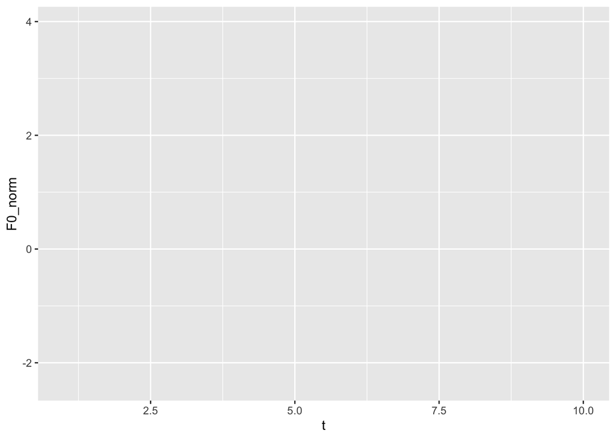

```r
#Make sure you have a visual understanding of what we are plotting. What data are on the x- and y-axis?
ggplot(f0_data_norm,
       aes(x = t, #specify time on the x axis
           y = F0_norm) #normalized F0
       )
```

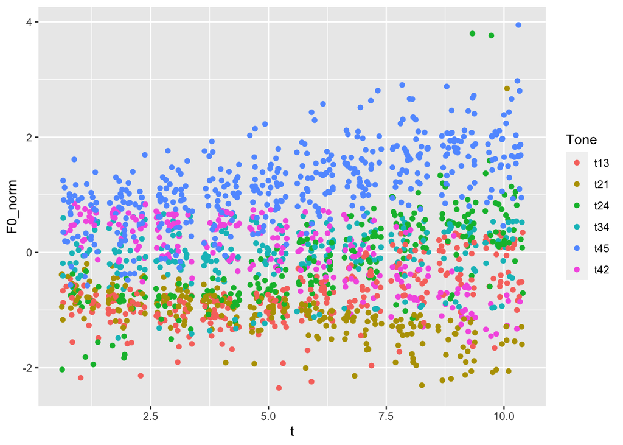

```r
#Plot f0 data point on the plotting space.
ggplot(f0_data_norm,
       aes(x = t, y = F0_norm,
           color = Tone)
       ) +
  geom_jitter()
```

But this is a little bit too messy, and we actually want to put each tone in separate panels. This can be achieved by using facet_wrap() or facet_grid() function from ggplot2.

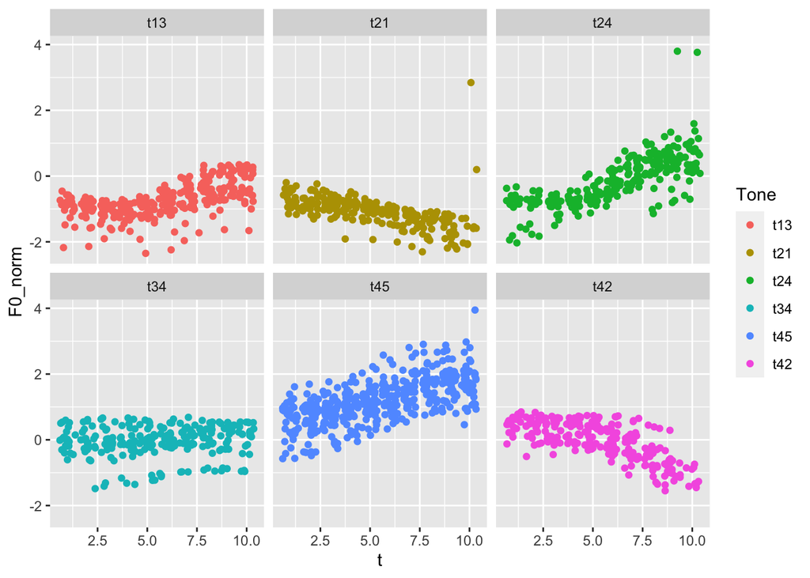

```r
ggplot(f0_data_norm,
       aes(x = t, y = F0_norm)
       ) +
  geom_jitter(aes(color = Tone)) +
  facet_wrap(~ Tone)
```

Can we improve plot by adding smoothing line to each tone?

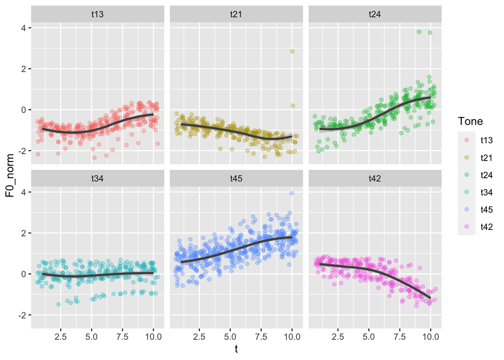

```r
ggplot(f0_data_norm,
       aes(x = t, y = F0_norm)
       ) +
  geom_jitter(aes(color = Tone), alpha = .3) + #add different color to each tone, and make the color of dots lighter
  geom_smooth(color = "grey30") +
  facet_wrap(~ Tone)
```

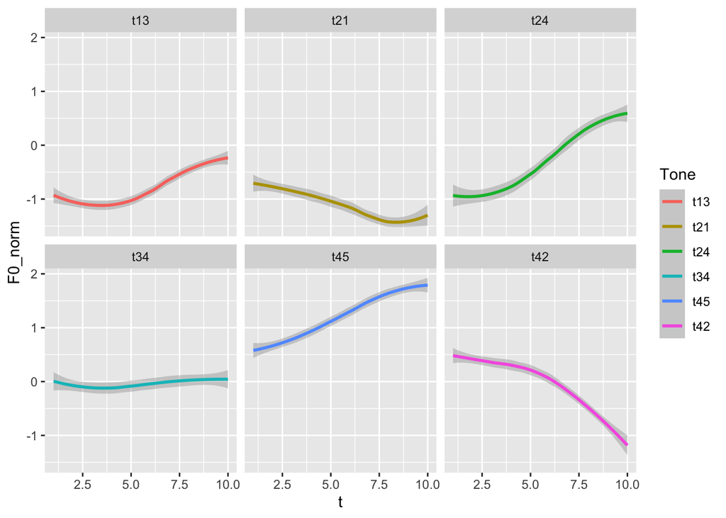

```r
ggplot(f0_data_norm,
       aes(x = t, y = F0_norm)
       ) +
  geom_smooth(aes(color = Tone)) +  #Now we need to specify color for the smooths
  facet_wrap(~ Tone)
```

If you are interested in the cross-speaker variability, we can also plot the raw f0 data and put the data from each speaker in different panels.

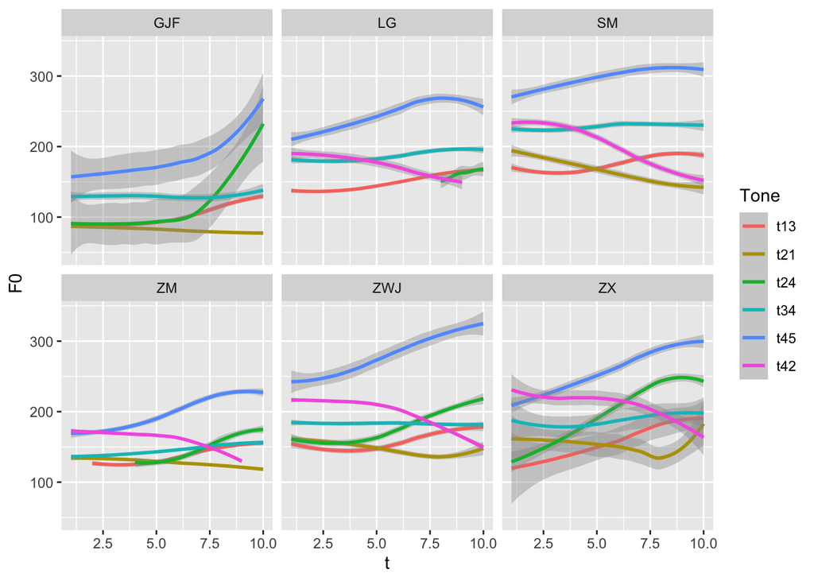

```r
ggplot(f0_data_norm,
       aes(x = t, y = F0) #Use F0 instead of F0_norm
       ) +
  geom_smooth(aes(color = Tone)) +
  facet_wrap(~ Speaker) #Now we facet the data by Speaker
```

As you can see, there seems to be lots of inter-speaker variablity that is worth further investigation by taking more data from more speakers.

# Formants

Formant data are pretty much just the same, but there is one single difference: while there is only one dependent variable F0() that is to be plotted on the y-axis, there are multiple dependent variables (usually, F1 and F2, occasionally F3) in formant data set. There are two alternative ways to plot them.

## Data import and cleaning

First of all, we still need to import the data into R. Since we have multiple files in the data folder, I wrote a function to read in multiple data files into R at once. You can check the detail of it by opening the script. Now let’s load the function into the current working environment.

```r
source("r_scripts/read_formant.R")
```

We then will create a list of files in the vowel folder under data folder.

```r
file_list <- list.files(path = "data/vowel", pattern = "*.txt", full.names = T)
```

Then we can use the lapply() function to apply the function I wrote to import all the data by applying read_formant() function to each of the file in the vowel folder. (lapply basically means “apply to list”)

```r
# Merge all data into one dataset
(formant <- lapply(file_list, read_formant) %>% reduce(bind_rows))
```

```
## # A tibble: 1,080 x 14
##    File_name Seg_num Seg   Tone      t   t_m    F1    F2    F3    F4   COG  sdev
##    <chr>     <chr>   <fct> <fct> <dbl> <dbl> <dbl> <dbl> <dbl> <dbl> <dbl> <dbl>
##  1 vowels.w… 2       ai    t1        1 0.046   801  1493  2440     0 11595  5645
##  2 vowels.w… 2       ai    t1        2 0.059   760  1519  2446     0 18584  4746
##  3 vowels.w… 2       ai    t1        3 0.072   752  1478  2475     0    66   439
##  4 vowels.w… 2       ai    t1        4 0.085   705  1439  2458     0    92   575
##  5 vowels.w… 2       ai    t1        5 0.098   709  1494  2454     0    36   361
##  6 vowels.w… 2       ai    t1        6 0.111   718  1533  2416     0    47   427
##  7 vowels.w… 2       ai    t1        7 0.124   720  1502  2418     0    54   495
##  8 vowels.w… 2       ai    t1        8 0.137   674  1542  2393     0    56   474
##  9 vowels.w… 2       ai    t1        9 0.15    676  1605  2378     0   259   951
## 10 vowels.w… 2       ai    t1       10 0.163   657  1679  2357     0   254   980
## # … with 1,070 more rows, and 2 more variables: skew <dbl>, kurt <dbl>
```

```r
glimpse(formant)
```

```
## Rows: 1,080
## Columns: 14
## $ File_name <chr> "vowels.wav", "vowels.wav", "vowels.wav", "vowels.wav", "vow…
## $ Seg_num   <chr> "2", "2", "2", "2", "2", "2", "2", "2", "2", "2", "2", "2", …
## $ Seg       <fct> ai, ai, ai, ai, ai, ai, ai, ai, ai, ai, ai, ai, ai, ai, ai, …
## $ Tone      <fct> t1, t1, t1, t1, t1, t1, t1, t1, t1, t1, t1, t1, t1, t1, t1, …
## $ t         <dbl> 1, 2, 3, 4, 5, 6, 7, 8, 9, 10, 11, 12, 13, 14, 15, 16, 17, 1…
## $ t_m       <dbl> 0.046, 0.059, 0.072, 0.085, 0.098, 0.111, 0.124, 0.137, 0.15…
## $ F1        <dbl> 801, 760, 752, 705, 709, 718, 720, 674, 676, 657, 655, 646, …
## $ F2        <dbl> 1493, 1519, 1478, 1439, 1494, 1533, 1502, 1542, 1605, 1679, …
## $ F3        <dbl> 2440, 2446, 2475, 2458, 2454, 2416, 2418, 2393, 2378, 2357, …
## $ F4        <dbl> 0, 0, 0, 0, 0, 0, 0, 0, 0, 0, 0, 0, 0, 0, 0, 0, 0, 0, 0, 0, …
## $ COG       <dbl> 11595, 18584, 66, 92, 36, 47, 54, 56, 259, 254, 288, 459, 17…
## $ sdev      <dbl> 5645, 4746, 439, 575, 361, 427, 495, 474, 951, 980, 1047, 12…
## $ skew      <dbl> -1, -3, 29, 22, 36, 30, 27, 30, 14, 14, 13, 11, 16, 14, 10, …
## $ kurt      <dbl> -0.2, 10.0, 1052.0, 618.0, 1582.0, 1118.0, 865.0, 1047.0, 23…
```

# Plot formant data

## Plot different formants as different dependent variables

The first way is to use multiple geom_smooth() calls but specify different y values in aes().

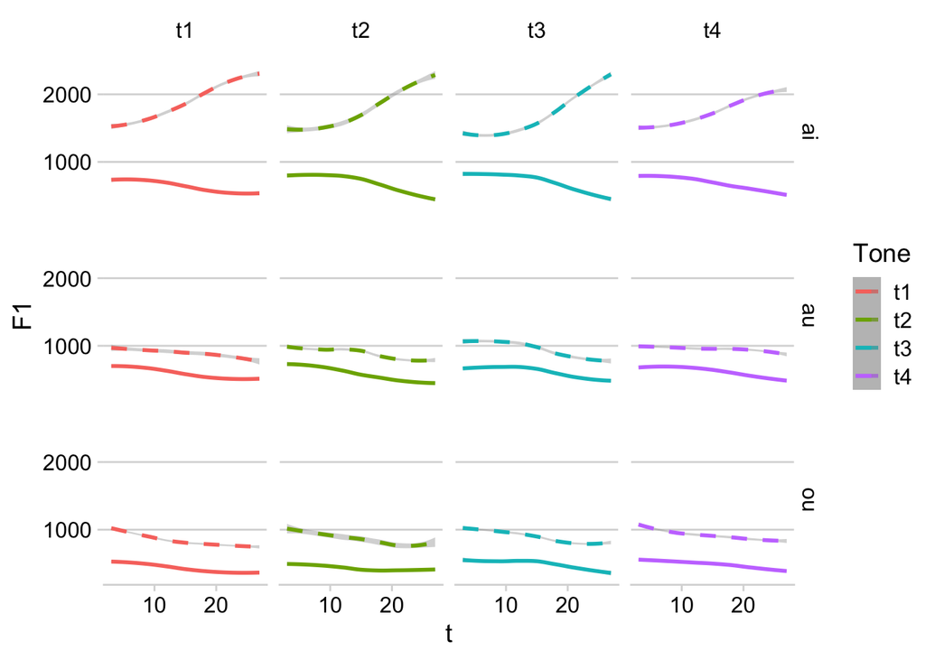

```r
ggplot(formant,
       aes(x = t, y = F1)) +
  geom_smooth(aes(color = Tone), linetype = 1) + # Plot F1 smooth lines
  geom_smooth(aes(y = F2, color = Tone), linetype = 2) + # Plot F2 smooth lines
  facet_grid(Seg ~ Tone) +
  xlim(3, 27) + # the formant values from the very beginning and end of the segements are usually unreliable
  coord_cartesian(ylim = c(300,2600)) +
  theme_minimal_hgrid() #Use the minimal horizontal grid theme from cowplot package
```

The other way is to transform the data and make all formant data in one column: “Hz”.

```r
(formant_2 <- formant %>%
  select(-F3, -F4, -COG, -sdev, -skew, -kurt) %>% # Get rid of F3, F4, and spectral data.
  pivot_longer(cols = c("F1", "F2"), names_to = "Formant", values_to = "Hz"))
```

```
## # A tibble: 2,160 x 8
##    File_name  Seg_num Seg   Tone      t   t_m Formant    Hz
##    <chr>      <chr>   <fct> <fct> <dbl> <dbl> <chr>   <dbl>
##  1 vowels.wav 2       ai    t1        1 0.046 F1        801
##  2 vowels.wav 2       ai    t1        1 0.046 F2       1493
##  3 vowels.wav 2       ai    t1        2 0.059 F1        760
##  4 vowels.wav 2       ai    t1        2 0.059 F2       1519
##  5 vowels.wav 2       ai    t1        3 0.072 F1        752
##  6 vowels.wav 2       ai    t1        3 0.072 F2       1478
##  7 vowels.wav 2       ai    t1        4 0.085 F1        705
##  8 vowels.wav 2       ai    t1        4 0.085 F2       1439
##  9 vowels.wav 2       ai    t1        5 0.098 F1        709
## 10 vowels.wav 2       ai    t1        5 0.098 F2       1494
## # … with 2,150 more rows
```

```r
glimpse(formant_2)
```

```
## Rows: 2,160
## Columns: 8
## $ File_name <chr> "vowels.wav", "vowels.wav", "vowels.wav", "vowels.wav", "vow…
## $ Seg_num   <chr> "2", "2", "2", "2", "2", "2", "2", "2", "2", "2", "2", "2", …
## $ Seg       <fct> ai, ai, ai, ai, ai, ai, ai, ai, ai, ai, ai, ai, ai, ai, ai, …
## $ Tone      <fct> t1, t1, t1, t1, t1, t1, t1, t1, t1, t1, t1, t1, t1, t1, t1, …
## $ t         <dbl> 1, 1, 2, 2, 3, 3, 4, 4, 5, 5, 6, 6, 7, 7, 8, 8, 9, 9, 10, 10…
## $ t_m       <dbl> 0.046, 0.046, 0.059, 0.059, 0.072, 0.072, 0.085, 0.085, 0.09…
## $ Formant   <chr> "F1", "F2", "F1", "F2", "F1", "F2", "F1", "F2", "F1", "F2", …
## $ Hz        <dbl> 801, 1493, 760, 1519, 752, 1478, 705, 1439, 709, 1494, 718, …
```

Now we only need one geom_smooth() call to plot both formants.

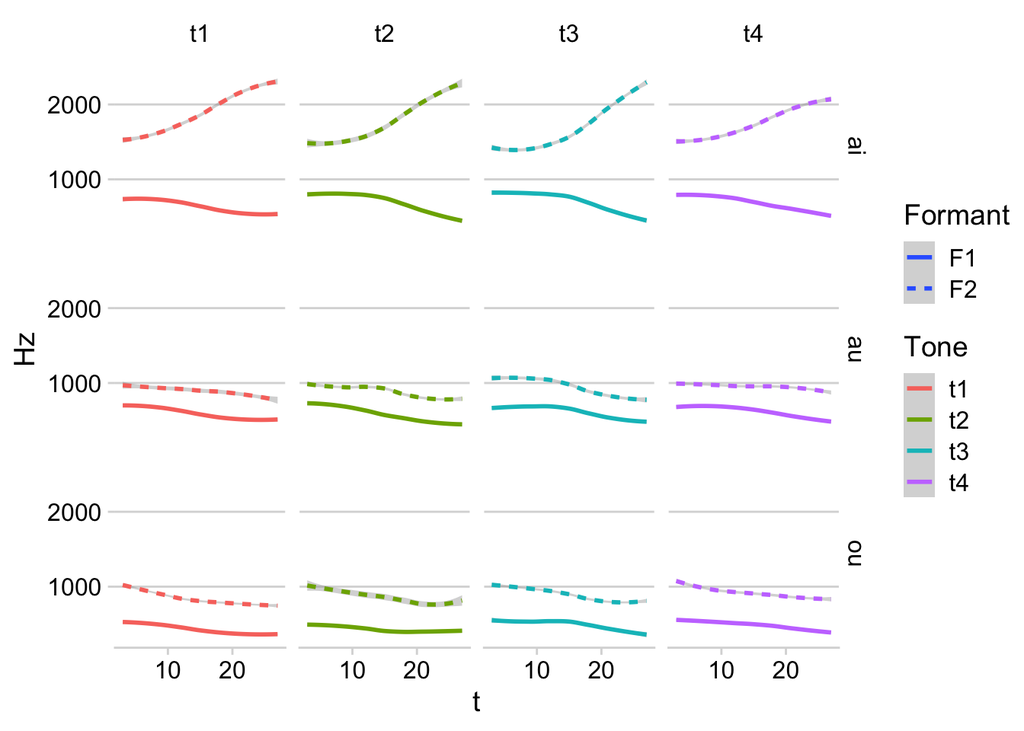

```r
ggplot(formant_2,
       aes(x = t, y = Hz)) +
  geom_smooth(aes(color = Tone, linetype = Formant)) + # Plot F1 and F2 smooth lines
  facet_grid(Seg ~ Tone) +
  xlim(3, 27) + # the formant values from the very beginning and end of the segements are usually unreliable
  coord_cartesian(ylim = c(300,2600)) +
  theme_minimal_hgrid()
```

We can also plot the measured time on the x-axis and show each individual data point as well.

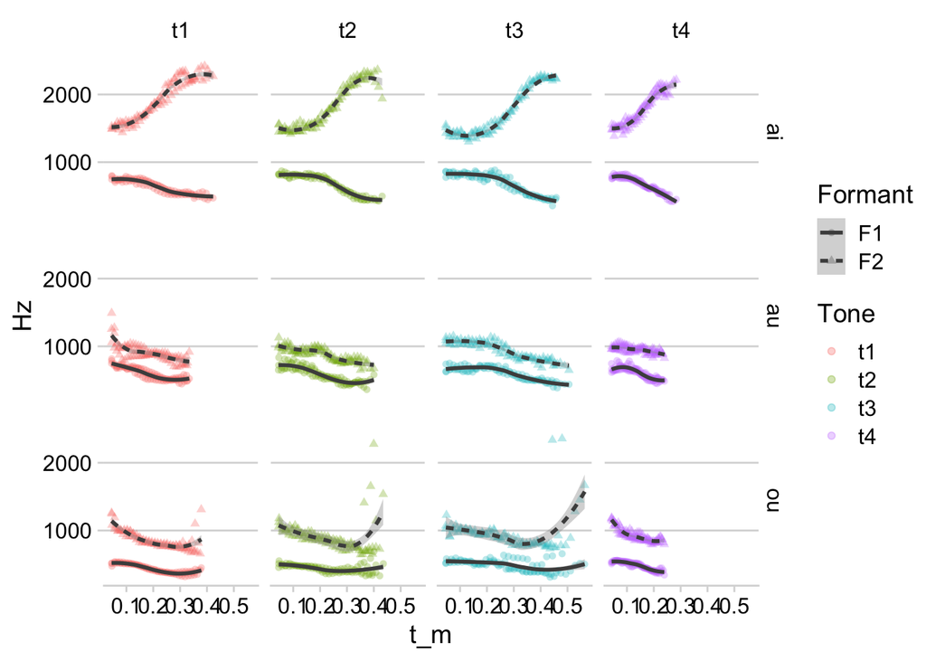

```r
ggplot(formant_2,
       aes(x = t_m, y = Hz)) +
  geom_jitter(aes(color = Tone, shape = Formant), alpha = .3) + # Plot F1 and F2 smooth lines
  geom_smooth(aes(linetype = Formant), color = "grey30") +
  facet_grid(Seg ~ Tone) +
  #xlim(3, 27) + # the formant values from the very beginning and end of the segements are usually unreliable
  coord_cartesian(ylim = c(300,2600)) +
  theme_minimal_hgrid()
```